# Manuscript draft

Author

Kaija Gahm, [others]

Published

March 29, 2024

# Introduction

#### We observe that some individuals are more central than others in a social network. What causes this variation?

##### Individual traits

- Multiple spatial behaviors → Social centrality (Albery et al. 2021)
- Exploration → Weak associations with more conspecifics, more movement between flocks. (Aplin et al. 2013)
- Slow-exploring → More stable relationships (Aplin et al. 2013)
- Personality → Social structure (Aplin et al. 2013)
- Stress → Weaker parental bonds, in captivity (Boogert et al. 2014)
- Stress → Foraging with more others, less choosy, more central, in captivity (Boogert et al. 2014)
- Stress → Foraging with more others, less choosy, more central, in the wild (Brandl et al. 2019)
- More exploratory → higher degree, in finches (Moyers et al. 2018)
- Quick explorers → More interactions (Moyers et al. 2018)
- Slower explorers → less central (“Yet, slower explorers overall did not travel shorter distances than faster explorers, indicating that a less central social network position was not merely a consequence of lower activity.”) (Snijders et al. 2014)
- Females → higher strength, more preferred partners (only during lactation) (Wey et al. 2013)
- Females → more stable partnerships (Wey et al. 2013)

#### Individuals’ spatial phenotypes are important determinants of their social centrality

Of course, how an animal uses space is also an important driver of how many conspecifics it interacts with, and how frequently. The relationship between movement, space use, and social interaction patterns has been an area of active research in recent years. Webber et al (2023a) have characterized the variation in patterns of animal movement and space use as the “spatial phenotype,” as part of a larger framework for understanding the relationships between social and spatial drivers of animal behavior. In this light, the “spatial phenotype” may be considered in addition to more conventional phenotypic measures to explain why some individuals are more central than others in their social networks.

- Definition of “spatial phenotype” (Webber et al. 2023a)
- Definition of “spatial behaviour” (Albery et al. 2021)
- Note that explicit spatial context is also important, and we didn’t consider it. (We should have! How do we justify not doing that?)
  - An individual’s observed spatial phenotype results from a combination of its internal tendency toward movement and the external environmental conditions through which it moves [(Nathan et al. 2008)](https://www.zotero.org/google-docs/?IyWvRB)

#### Social interactions occur when individuals encounter each other, in various behavioral situations.

- Co-occurrence in space and time is necessary for social interaction to occur. Therefore, more movement → more social interaction, in general.
- However, movement is also an expression of an individual’s underlying tendency to move, as well as potentially an emergent consequence of things like dominance rank or social environment.
- Social centrality arises from a combination of the number of interactions (strength) and unique individuals encountered. An individual can achieve high social centrality by being more geographically central in the population, versus by being more versatile.
- No one has investigated the link between spatial phenotype and social centrality. We know that individuals vary in both spatial phenotype and social centrality, but we don’t know how the one influences the other.
  - Furthermore, social networks are not monolithic. Because the biological mechanisms behind social network structure are different in different social situations, it stands to reason that spatial phenotype should be related to social centrality in different ways in the different social contexts.
    - For example, different components of spatial phenotype might be expected to relate differently to networks in different social situations.
    - Also, we might just see different-direction effects. For example, individuals that move a lot might interact more frequently in flight but interact less frequently at feeding stations (either because they spend less time feeding or because they feed at more peripheral locations). Therefore, it is important to consider different behavioral situations separately when teasing apart the relationship between the social and spatial phenotypes.

#### We set out to uncover whether spatial phenotypes could explain observed variation in social centrality.

- Hypotheses/predictions from slides

##### Research Questions

Q1: What is the relationship between spatial phenotype and social interactions?

- H1A: Individuals that move more will have more, and stronger, encounters with other unique individuals.
  - P1A: Vultures that move more will encounter more others (higher degree centrality in the social network) and have more interactions (higher strength in the social network) than vultures who move less.
- H1B: Individuals that are more exploratory will have more but weaker encounters with other unique individuals.
  - P1B: Exploratory vultures will encounter more unique individuals (higher degree centrality), but will have fewer interactions (lower strength) compared to less exploratory vultures.

Q2: How is the relationship between spatial phenotype and social interactions impacted by social situation and season?

- H2A: Social situations in which animals move more will have a greater impact on social interactions
  - P2A: Social centrality in co-flight networks will be more strongly associated with spatial phenotype than in co-roosting and co-feeding behavioral situations.
- H2B: Seasons in which animals move more will have a stronger impact on social interactions
  - P2B: The relationship between movement and social position will be stronger in the non-breeding seasons (summer and fall) than during the breeding season.

# Methods

### Study system

Griffon vultures interact in several social situations, each with a different biological relevance. In particular, griffons rely on social information to locate food resources. Interactions in flight (i.e. when individuals fly within each other’s perceptual distance) provide an opportunity for local enhancement of carcass resources, or following to a carcass site. Therefore, they are important for information transfer (Harel et al. 2017), finding locations of thermal uplift (Sassi et al. 2023), and feeding sites (Spiegel et al. 2013; Cortés-Avizanda et al. 2014). Vultures also obtain social information about food resources at communal roosting sites. Roost sites can vary in size and density, with many vultures roosting together at once. These roosts also serve as breeding colonies during the breeding season (approximately December through May). Finally, vultures interact frequently at or around carcasses while eating. The free-living griffon vultures in the southern Israel population are provisioned at several feeding sites, where livestock carcasses are deposited irregularly to supplement the availability of naturally-occurring carcasses on the landscape. Vultures may co-feed, associate in close proximity near a carcass, or even fight over the food resource.

## Data preparation

For this study, we used data between September 1, 2020 and September 15, 2023 from the [ornitela] and [inpa] datasets, which we downloaded from Movebank (Kays et al. 2022). For each vulture, we removed any periods of time spent in the wildlife hospital (e.g. while recovering from an illness, injury, or poisoning), or in captivity prior to wild release (in the case of captive-born birds). We cleaned the data by filtering out GPS fixes deemed unreliable (e.g. too few satellites for triangulation, nonsensical heading readings, impossible jumps from previous fixes), and we removed any time that vultures spent in capture cages during the tagging season in the fall. Altogether, approximately 0.64% of fixes were removed as compared to the raw data. Next, we removed any vultures that spent fewer than 30 days, in total, within a focal region encompassing the general vicinity of Israel (in order to exclude, for instance, birds that were briefly detected in the area before dispersing far away). For vultures detected in the area for at least 30 days during the study period, we subsequently removed any fixes for those individuals that occurred outside of the same focal region, in order to restrict our analyses to movements that occurred near the main population locus and ensure that most social interactions would be with other tagged individuals. (We accounted for missing time periods, including removed data, by calculating association indices in the social networks).

We divided the remaining data into seasons based on biological knowledge of vultures’ breeding timelines: a breeding season (December 15 through May 14 of the following year); a summer or post-breeding season (May 15th through September 14th), and a transient or pre-breeding season (September 15th through December 14th). For simplicity, we refer to each breeding season by the calendar year in which it ends (e.g. the 2021 breeding season lasts from December 15, 2020 through May 14, 2021). We analyzed data from the 2020 pre-breeding/transient season through the 2023 post-breeding/summer season, for a total of nine seasons across four calendar years (three of each type of season).

The vulture population in Israel is geographically separated, with most individuals in the south but a small and relatively isolated population at the Hai Bar Carmel Nature Reserve and in the Golan Heights. While vultures occasionally move between the northern and southern population, such movements are rare, and northern vultures behave differently than southern vultures due to more consistent feeding and a more restricted range in the north. Therefore, for each season, we restricted our analysis to individuals whose spatial centroid (including all GPS points after data cleaning) lay south of UTM Northing 3550000 (Zone 36N), equivalent to approximately 32.086238 North latitude. This threshold was determined by visual examination of a histogram of centroid latitudes, which was bimodal and disjoint. Finally, to account for older GPS tags that were set to lower fix frequencies, we excluded any individuals from each season that never had their tags set to a 10-minute frequency during that season. In recent months, some tags were temporarily set to record fixes at much higher frequencies, so those individuals were downsampled to a 10-minute frequency in order to make data analysis more tractable.

After this cleaning, the data used for social network analysis contained 120 unique vultures in total (range: 33-91; mean = 65.78 vultures per season, sd = 21.57 vultures per season).

#### Determining roost locations

We used GPS fixes to determine vultures’ nightly roost locations. The solar-powered GPS tags are set to record very few fixes overnight, and cell reception (needed for data transmission) is often very poor on the cliffs where roosting sites are located. Therefore, we combined information from individuals’ last locations of the evening and first locations of the morning to assign a roost site for each individual on each night. Full details about the data cleaning and roost assignment procedure can be found in the supplementary material.

#### Further cleaning for movement analysis

To characterize individual movement behavior and spatial phenotype, we cleaned the data further. We restricted movement points to the period between sunrise and sunset (calculated for each day with respect to a point at the centroid of Israel using the R package {suncalc} (Thieurmel and Elmarhraoui 2022). We restricted movement calculations to a set of focal individuals with activity regions centered in the Negev region of Israel, the site of most of our tagging effort. For each vulture, we also removed days with too few GPS fixes. Fixes were ideally collected every 10 minutes, but sometimes they were less frequent due to bad cellular reception in the cliff areas where vultures often sit or due to low battery charge. For each individual, only days with 10 or more GPS fixes per day were retained, unless the battery charge remained above 50% for the entire day. In those cases, the low number of points was attributed to the vultures spending most of their time sitting on a cliff (with limited reception) without much movement, rather than to actual missing data due to low battery. Since these sedentary days represent an important component of vulture movement behavior, we retained this information (Orr Spiegel, pers. obs.).

After removing days with too few fixes per day, we removed any vultures that did not have at least 30 days of valid movement data remaining in a given season, to ensure that movement estimates and averages were based on a high enough sample size of days to capture the range of the vulture’s behavior. Since this was done on a per-season basis, individuals that were removed from one season’s analysis due to not having enough valid days could still have movement measures calculated for a different season. Finally, we downsampled the movement data to a 10-minute interval to remove high-frequency fixes. Ultimately, we calculated movement measures for a total of 117 **focal individuals** in total (range: 28-86; mean = 57.89 vultures per season, sd = 21.75 vultures per season).

## Measuring spatial phenotype

We characterized the pattern-based spatial phenotype (Webber et al. 2023b) of each focal individual by measuring its overall space use, use of roost sites, and movement patterns.

We calculated seasonal home ranges and core areas using autocorrelated kernel density estimates (AKDEs) via the {ctmm} R package (Fleming and Calabrese 2023). We defined the home range as the 95% AKDE and the core area as the 50% AKDE. To measure differences in how individuals used their home ranges, we calculated the ratio of the seasonal core area size to the seasonal home range size.

We identified in-flight fixes (ground speed >= 5 m/s) and calculated measures of daily flight behavior, including maximum and median daily flight altitude and daily flight time (the sum of time intervals between adjacent in-flight fixes). We calculated flight altitude by extracting ground elevation information from elevation rasters obtained from the {elevatr} package at a ground resolution of approximately 250 meters (Hollister et al. 2022) and subtracting those numbers from the vultures’ tag-mounted altimeter readings. Finally, we used all fixes to calculate daily distance traveled (the sum of all distances between successive fixes); daily maximum displacement (the straight-line distance between the beginning of the daily movement track and the farthest point reached on that day); and movement tortuosity (cumulative distance to the point of maximum displacement divided by the straight-line distance to the point of maximum displacement (Benhamou 2004)). We took seasonal means of each of these individual daily measures to get a single value per individual, per season.

## Summarizing movement measures

We characterized individuals’ spatial phenotypes using three composite indices: movement, space use, and roost diversification. Each index was derived from a principal component analysis of several spatial phenotype variables, each scaled and centered over the entire date range of the study.

While the griffon vulture population in southern Israel is fairly well mixed and vultures do not have discrete, exclusive territories, there is still variability in where individuals spend their time within the landscape. Spatial position has the potential to directly affect how many other individuals a vulture encounters and which feeding and roost sites it frequents. In addition, though a high proportion of the vultures in the area are GPS-tagged, more peripheral vultures might be more likely to interact with untagged birds living farther from the population center, potentially diluting their measured measured strength or degree. To account for the influence of geographic centrality on social centrality, we calculated the geographic centroid of all GPS points for each individual in each season. Then we compared these centroids to the overall centroid of all individuals in the population in that season to obtain an index of centrality (versus peripherality). We incorporated spatial centrality as a covariate into our linear models.

## Construction of proximity-based social networks

Using GPS fixes from the tagged vultures, we created weighted, undirected proximity-based social networks in three different social situations for each of the nine seasons, following Sharma (2023): co-flight, co-feeding (diurnal ground interactions) and co-roosting (nocturnal ground interactions). Because not all individuals were tagged for exactly the same period of time, and to account for missing data due to low tag battery or poor reception, we calculated the simple ratio index (SRI) to quantify the strength of the association between each pair of vultures in each social situation. We calculated SRI by dividing the number of 10-minute time periods during which two vultures were observed interacting by the number of time periods during which both vultures had a recorded GPS fix (whether or not they were interacting during that period) (Ginsberg and Young 1992). Thus, two vultures who never interacted in a given social situation would have an SRI of 0, while two individuals who were interacting in every time period during which a GPS fix was collected for both of them would have an SRI of 1.

Non-focal vultures (e.g. those that did not always have enough points per day, or those that were not tracked for at least 30 days per season) were included in our calculations of social interactions. Even if an individual did not have enough data to calculate meaningful movement measures, it could still contribute to a focal individual’s position in the social network. Defining edge weights with SRI ensured that missing data for these non-focal birds did not bias edge weight estimates for their social relationships.

### Co-flight

Vultures were considered to be flying if their ground speed (collected by a sensor on the GPS tags) was > 5 m/s (Spiegel et al. 2013) . Because vultures can see each other over long distances (Pennycuick 1972; Spiegel, Getz, and Nathan 2013) , and in accordance with (Sharma et al. 2023), we defined a co-flight interaction as two individuals flying within 1000m of each other for at least two consecutive 10-minute time periods.

### Co-feeding

Vultures that were not flying (ground speed < 5 m/s, (Spiegel et al. 2013)) who came within 50m of each other for at least two consecutive 10-minute time periods, were considered to be having a ground interaction (Sharma et al. 2023). Any ground interactions that occurred at night or within the boundaries of a known roost site were excluded. Therefore, the remaining diurnal ground interactions should represent vultures’ interactions while feeding or while present at feeding sites (Orr Spiegel and Nili Anglister, pers. comm.).

### Co-roosting

Vultures were considered to be co-roosting if they roosted within 500m of each other on a given night. Unlike interactions in the co-feeding and co-flight networks, co-roosting interactions could occur at a maximum frequency of once per night. Therefore, edge weights in the co-roosting network represented the number of nights on which two individuals co-roosted divided by the number of nights when both individuals had a valid roost location (i.e. they theoretically could have co-roosted), regardless of proximity.

## Calculation of social network measures

We used the R package {igraph} (Csardi and Nepusz 2005) to calculate each individual’s degree and strength for each social situation in each season. Degree is defined as the number of other individuals that a vulture is connected to (i.e. ever interacted with). Strength measures how much an individual interacts, and is calculated as the sum of the weights of all edges that the focal vulture is involved in.

## Model fitting and selection

Degree values were scaled and standardized before modeling. Because the distribution of strength values was extremely right-skewed, the strength values were incremented by one-half the minimum non-zero strength value (0.018) and then log-transformed.

For each response variable, we began by fitting a model without any interaction terms to check for multicollinearity between the predictors and check model assumptions, using the {performance} and {DHARMa} packages (Lüdecke et al. 2021; Hartig 2022). Next, we fitted a model containing two three-way interaction terms (between season, situation, and each of the spatial phenotype variables), all of the included two-way interaction terms, age as a main effect, and the two random effects (individual ID; season by year). Examining the model summaries and p values produced by lmerTest, we then removed non-significant higher-order interaction terms, one by one, stopping when all remaining interaction terms were significant. All main and random effects were retained in the final model.

For each model, we calculated marginal effects using the {emmeans} package (Lenth 2023) and created visualizations using {ggeffects} and {ggplot2} (Wickham 2016; Lüdecke 2018).

# Results

## Degree

```r
# NOT SHOW
plot_d_eff_space # null--no overall relationship between space use and degree
```

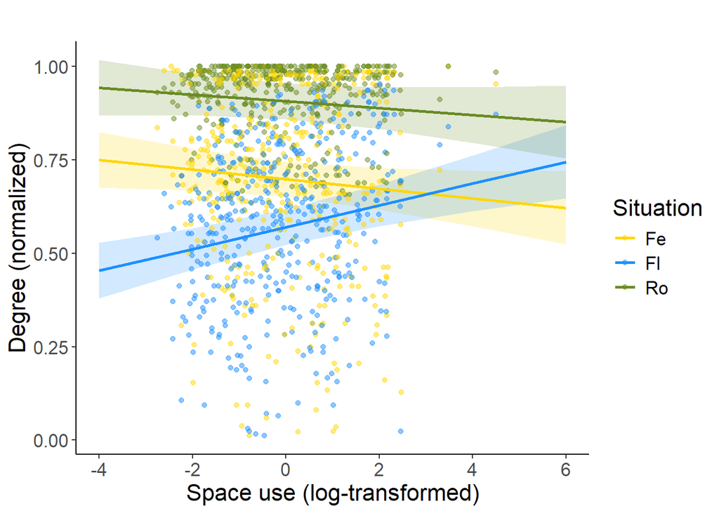

Figure 1: Relationship between normalized degree and space use, with separate trend lines for each social situation

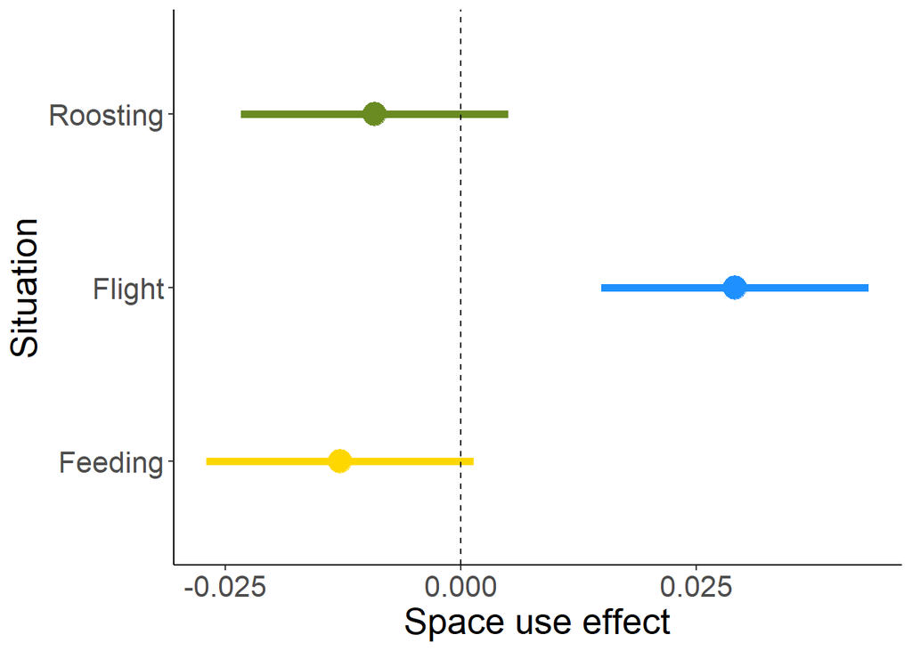

```r
plot_d_eff_situ_space
plot_d_emt_situ_space
```

There was a significant relationship between how vultures used space and how many other individuals they encountered in flight. Vultures that consistently ranged widely encountered more others in flight, while those that concentrated their movement in smaller home ranges and smaller proportional core areas flew with fewer others. There was a slight, albeit non-statistically-significant, trend toward lower degree in the co-feeding and co-roosting networks for vultures with larger ranges.

```r
# NOT SHOW
plot_d_eff_roost # null--no overall relationship between roost diversification and degree
```

```r
# NOT SHOW
plot_d_eff_situ_movement
plot_d_emt_situ_movement # going to show the plot by season instead of this one
```

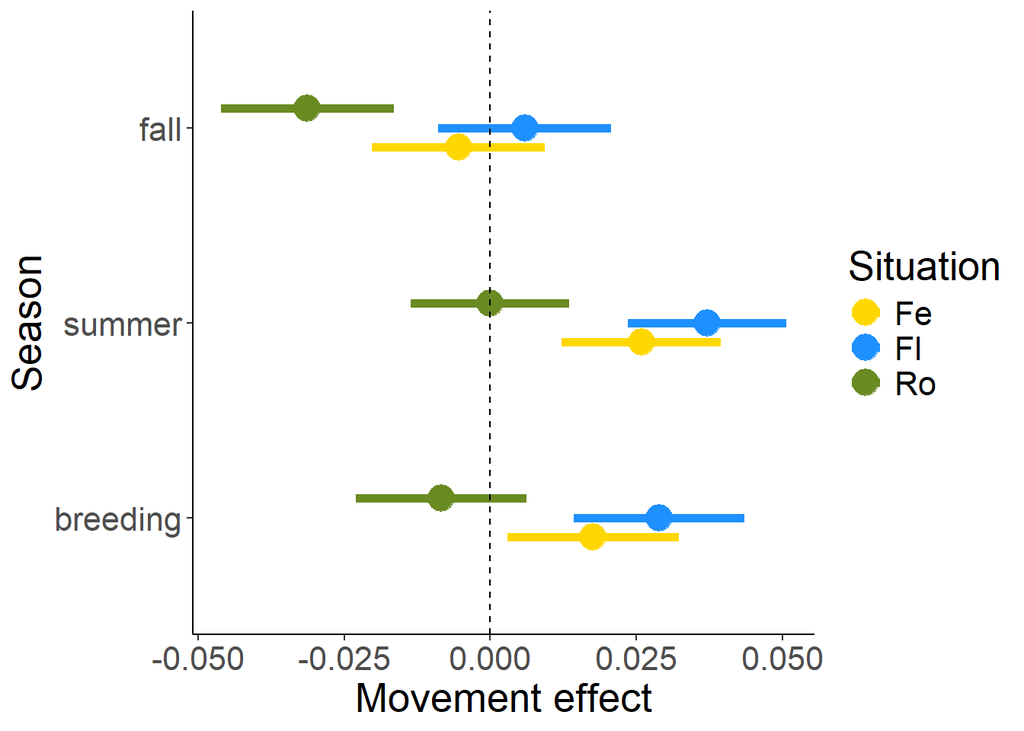

Figure 3: Relationship between normalized degree and movement, for each season and social situation.

```r
plot_d_emt_situ_movement_season
```

Movement behavior affected degree in all three social situations. Vultures with a higher movement score co-roosted with fewer conspecifics only in the transient, pre-breeding season; otherwise movement did not affect their co-roosting degree. In the breeding and post-breeding seasons, vultures that moved more encountered more conspecifics in flight and while feeding, but this relationship did not hold in the pre-breeding season.

## Strength

```r
plot_s_eff_movement # null
```

[output not shown]

There was no relationship between movement and strength, either overall or in any season or situation.

```r
plot_s_eff_roost
```

[output not shown]

However, individuals with more diversified roosts had lower strength (i.e. they interacted less) overall, considering seasons and situations together.

```r
plot_s_eff_situ_space
plot_s_emt_situ_space
```

[output not shown]

Vultures with greater space use had significantly more co-flight interactions (higher strength in the co-flight network). They also tended to have a higher co-roosting strength, though the trend was not statistically significant. There was no relationship between seasonal space use and co-feeding strength.

## Discussion

Albery, Gregory F., Lucinda Kirkpatrick, Josh A. Firth, and Shweta Bansal. 2021. “Unifying Spatial and Social Network Analysis in Disease Ecology.” *Journal of Animal Ecology* 90 (1): 45–61. https://doi.org/10.1111/1365-2656.13356.

Aplin, L. M., D. R. Farine, J. Morand-Ferron, E. F. Cole, A. Cockburn, and B. C. Sheldon. 2013. “Individual Personalities Predict Social Behaviour in Wild Networks of Great Tits (Parus Major).” *Ecology Letters* 16 (11): 1365–72. https://doi.org/10.1111/ele.12181.

Balasubramaniam, Krishna N., Brianne A. Beisner, Josephine A. Hubbard, Jessica J. Vandeleest, Edward R. Atwill, and Brenda McCowan. 2019. “Affiliation and Disease Risk: Social Networks Mediate Gut Microbial Transmission Among Rhesus Macaques.” *Animal Behaviour* 151 (May): 131–43. https://doi.org/10.1016/j.anbehav.2019.03.009.

Bates, Douglas, Martin Mächler, Ben Bolker, and Steve Walker. 2015. “Fitting Linear Mixed-Effects Models Using Lme4.” *Journal of Statistical Software* 67 (1): 148. https://doi.org/10.18637/jss.v067.i01.

Benhamou, Simon. 2004. “How to Reliably Estimate the Tortuosity of an Animal’s Path:: Straightness, Sinuosity, or Fractal Dimension?” *Journal of Theoretical Biology* 229 (2): 209–20. https://doi.org/10.1016/j.jtbi.2004.03.016.

Boogert, Neeltje J., Glenna F. Nightingale, William Hoppitt, and Kevin N. Laland. 2014. “Perching but not foraging networks predict the spread of novel foraging skills in starlings.” *Behavioural Processes* 109 Pt B (November): 135–44. https://doi.org/10.1016/j.beproc.2014.08.016.

Brandl, Hanja B., Damien R. Farine, Caterina Funghi, Wiebke Schuett, and Simon C. Griffith. 2019. “Early-Life Social Environment Predicts Social Network Position in Wild Zebra Finches.” *Proceedings of the Royal Society B: Biological Sciences* 286 (1897): 20182579. https://doi.org/10.1098/rspb.2018.2579.

Corner, L. A. L, D. U Pfeiffer, and R. S Morris. 2003. “Social-Network Analysis of Mycobacterium Bovis Transmission Among Captive Brushtail Possums (Trichosurus Vulpecula).” *Preventive Veterinary Medicine* 59 (3): 147–67. https://doi.org/10.1016/S0167-5877(03)00075-8.

Cortés-Avizanda, Ainara, Roger Jovani, José Antonio Donázar, and Volker Grimm. 2014. “Bird Sky Networks: How Do Avian Scavengers Use Social Information to Find Carrion?” *Ecology* 95 (7): 1799–1808. https://doi.org/10.1890/13-0574.1.

Csardi, Gabor, and Tamas Nepusz. 2005. “The Igraph Software Package for Complex Network Research.” *InterJournal* Complex Systems (November): 1695.

Fleming, Christen H., and Justin M. Calabrese. 2023. *Ctmm: Continuous-Time Movement Modeling*. https://github.com/ctmm-initiative/ctmm.

Ginsberg, Joshua R., and Truman P. Young. 1992. “Measuring Association Between Individuals or Groups in Behavioural Studies.” *Animal Behaviour* 44 (August): 377–79. https://doi.org/10.1016/0003-3472(92)90042-8.

Godfrey, Stephanie S., C. Michael Bull, Richard James, and Kris Murray. 2009. “Network Structure and Parasite Transmission in a Group Living Lizard, the Gidgee Skink, Egernia Stokesii.” *Behavioral Ecology and Sociobiology* 63 (7): 1045–56. https://doi.org/10.1007/s00265-009-0730-9.

Harel, Roi, Olivier Duriez, Orr Spiegel, Julie Fluhr, Nir Horvitz, Wayne M. Getz, Willem Bouten, François Sarrazin, Ohad Hatzofe, and Ran Nathan. 2016. “Decision-Making by a Soaring Bird: Time, Energy and Risk Considerations at Different Spatio-Temporal Scales.” *Philosophical Transactions of the Royal Society B: Biological Sciences* 371 (1704). https://doi.org/10.1098/rstb.2015.0397.

Harel, Roi, Orr Spiegel, Wayne M. Getz, and Ran Nathan. 2017. “Social Foraging and Individual Consistency in Following Behaviour: Testing the Information Centre Hypothesis in Free-Ranging Vultures.” *Proceedings of the Royal Society B: Biological Sciences* 284 (1852): 20162654. https://doi.org/10.1098/rspb.2016.2654.

Hartig, Florian. 2022. “DHARMa: Residual Diagnostics for Hierarchical (Multi-Level / Mixed) Regression Models.” https://CRAN.R-project.org/package=DHARMa.

Hollister, Jeffrey, Tarak Shah, Alec L. Robitaille, Marcus W. Beck, and Mike Johnson. 2022. “Elevatr: Access Elevation Data from Various APIs.” https://doi.org/10.5281/zenodo.5809645.

Kays, Roland, Sarah C. Davidson, Matthias Berger, Gil Bohrer, Wolfgang Fiedler, Andrea Flack, Julian Hirt, et al. 2022. “The Movebank System for Studying Global Animal Movement and Demography.” *Methods in Ecology and Evolution* 13 (2): 419–31. https://doi.org/10.1111/2041-210X.13767.

Kuznetsova, Alexandra, Per B. Brockhoff, and Rune H. B. Christensen. 2017. “lmerTest Package: Tests in Linear Mixed Effects Models.” *Journal of Statistical Software* 82 (13): 126. https://doi.org/10.18637/jss.v082.i13.

Lenth, Russell V. 2023. “Emmeans: Estimated Marginal Means, Aka Least-Squares Means.” https://CRAN.R-project.org/package=emmeans.

Lloyd-Smith, J. O., S. J. Schreiber, P. E. Kopp, and W. M. Getz. 2005. “Superspreading and the Effect of Individual Variation on Disease Emergence.” *Nature* 438 (7066): 355–59. https://doi.org/10.1038/nature04153.

Lüdecke, Daniel. 2018. “Ggeffects: Tidy Data Frames of Marginal Effects from Regression Models.” *Journal of Open Source Software* 3 (26): 772. https://doi.org/10.21105/joss.00772.

Lüdecke, Daniel, Mattan S. Ben-Shachar, Indrajeet Patil, Philip Waggoner, and Dominique Makowski. 2021. “Performance: An r Package for Assessment, Comparison and Testing of Statistical Models.” *Journal of Open Source Software* 6 (60): 3139. https://doi.org/10.21105/joss.03139.

Moyers, Sahnzi C., James S. Adelman, Damien R. Farine, Ignacio T. Moore, and Dana M. Hawley. 2018. “Exploratory Behavior Is Linked to Stress Physiology and Social Network Centrality in Free-Living House Finches (Haemorhous Mexicanus).” *Hormones and Behavior* 102 (June): 105–13. https://doi.org/10.1016/j.yhbeh.2018.05.005.

Pennycuick, C. J. 1972. “Soaring Behaviour and Performance of Some East African Birds, Observed from a Motor-Glider.” *Ibis* 114 (2): 178–218. https://doi.org/10.1111/j.1474-919X.1972.tb02603.x.

Romano, Valéria, Julie Duboscq, Cécile Sarabian, Elodie Thomas, Cédric Sueur, and Andrew J. J. MacIntosh. 2016. “Modeling Infection Transmission in Primate Networks to Predict Centrality-Based Risk.” *American Journal of Primatology* 78 (7): 767–79. https://doi.org/10.1002/ajp.22542.

Sah, Pratha, Stephan T. Leu, Paul C. Cross, Peter J. Hudson, and Shweta Bansal. 2017. “Unraveling the Disease Consequences and Mechanisms of Modular Structure in Animal Social Networks.” *Proceedings of the National Academy of Sciences* 114 (16): 4165–70. https://doi.org/10.1073/pnas.1613616114.

Sassi, Yohan, Basile Nouzières, Martina Scacco, Yann Tremblay, Olivier Duriez, and Benjamin Robira. 2023. “The Use of Social Information in Vulture Flight Decisions.” https://doi.org/10.1101/2023.07.26.550671.

Sharma, Nitika, Nili Anglister, Orr Spiegel, and Noa Pinter-Wollman. 2023. “Social Situations Differ in Their Contribution to Population-Level Social Structure in Griffon Vultures.” *Ecology and Evolution* 13 (6): e10139. https://doi.org/10.1002/ece3.10139.

Silk, Joan, Dorothy Cheney, and Robert Seyfarth. 2013. “A Practical Guide to the Study of Social Relationships.” *Evolutionary Anthropology: Issues, News, and Reviews* 22 (5): 213–25. https://doi.org/10.1002/evan.21367.

Silk, Matthew J., Darren P. Croft, Richard J. Delahay, David J. Hodgson, Nicola Weber, Mike Boots, and Robbie A. McDonald. 2017. “The Application of Statistical Network Models in Disease Research.” *Methods in Ecology and Evolution* 8 (9): 1026–41. https://doi.org/10.1111/2041-210X.12770.

Snijders, Lysanne, Erica P. van Rooij, John M. Burt, Camilla A. Hinde, Kees van Oers, and Marc Naguib. 2014. “Social Networking in Territorial Great Tits: Slow Explorers Have the Least Central Social Network Positions.” *Animal Behaviour* 98 (December): 95–102. https://doi.org/10.1016/j.anbehav.2014.09.029.

Spiegel, Orr, Wayne M. Getz, and Ran Nathan. 2013. “Factors Influencing Foraging Search Efficiency: Why Do Scarce Lappet-Faced Vultures Outperform Ubiquitous White-Backed Vultures?” *The American Naturalist* 181 (5): E102–15. https://doi.org/10.1086/670009.

Spiegel, Orr, Roi Harel, Wayne M. Getz, and Ran Nathan. 2013. “Mixed Strategies of Griffon Vultures’ (Gyps Fulvus) Response to Food Deprivation Lead to a Hump-Shaped Movement Pattern.” *Movement Ecology* 1 (1): 5. https://doi.org/10.1186/2051-3933-1-5.

Thieurmel, Benoit, and Achraf Elmarhraoui. 2022. “Suncalc: Compute Sun Position, Sunlight Phases, Moon Position and Lunar Phase.” https://CRAN.R-project.org/package=suncalc.

Webber, Quinn M. R., Gregory F. Albery, Damien R. Farine, Noa Pinter-Wollman, Nitika Sharma, Orr Spiegel, Eric Vander Wal, and Kezia Manlove. 2023a. “Behavioural Ecology at the Spatialsocial Interface.” *Biological Reviews* 98 (3): 868–86. https://doi.org/10.1111/brv.12934.

———. 2023b. “Behavioural Ecology at the Spatialsocial Interface.” *Biological Reviews* 98 (3): 868–86. https://doi.org/10.1111/brv.12934.

Wey, Tina W., Joseph R. Burger, Luis A. Ebensperger, and Loren D. Hayes. 2013. “Reproductive Correlates of Social Network Variation in Plurally Breeding Degus (Octodon Degus).” *Animal Behaviour* 85 (6): 1407–14. https://doi.org/10.1016/j.anbehav.2013.03.035.

Wickham, Hadley. 2016. *Ggplot2: Elegant Graphics for Data Analysis*. Springer-Verlag New York. https://ggplot2.tidyverse.org.